# Children living in households with income below the national poverty line in 2020

[figure not shown]

This analysis focuses on the *number of children living in households with income below the national poverty line in 2020*. The data was obtained from the UNICEF database, which contains information on various indicators related to child well-being.We will also look at GDP per capita to see the relationship.

# Background

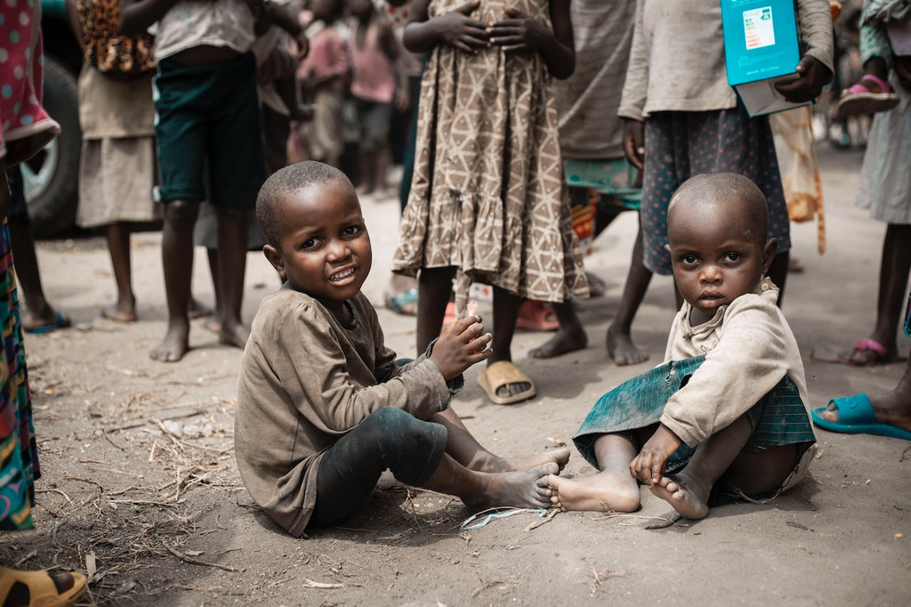

Children living in households with income below the national poverty line face numerous challenges that can impact their overall well-being and future prospects. These include limited access to:

- quality education
- healthcare
- healthy food
- safe living conditions

They may also experience *stress*, *trauma* and *social stigma* associated with their economic status. Addressing the needs of children from low-income families is essential to promote social equity and build a stronger, healthier and more prosperous society.

# World Map

The first visualization created was a world map showing the percentage of children living in households with income below the national poverty line. The map was created using the ggplot2 and maps packages in R. The map shows countries in different shades of blue, with darker colors indicating higher levels of poverty.

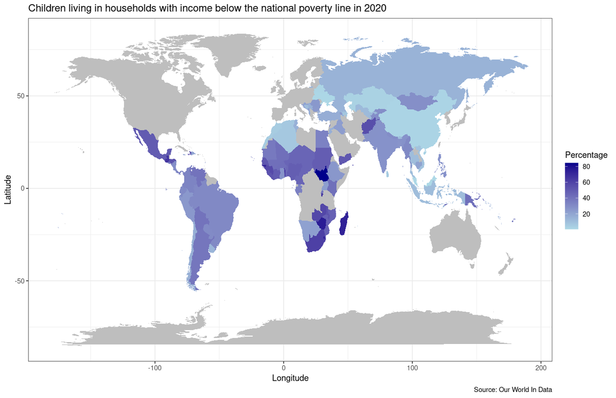

### Insights

In other words, a high growth of GDP can more often than not help to lessen poverty. GDP growth therefore has a close relationship with the poverty levels in any country. In fact, most economists believe that economic growth benefits nearly all citizens of a country, if not equally, at least in reducing poverty.

# Bar Chart

The second visualization created was a bar chart showing the GDP among the countries. The number of children living in poverty by country is affected by the GDP. The chart was created using the ggplot2 package in R.

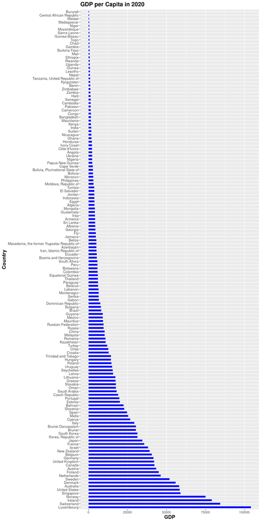

From this bar chart, we can see that most African countries have lower GDP than European Countries. Let’s further view the GDP in African countries.

### African Countries

Let’s compare the GDP among African countries.

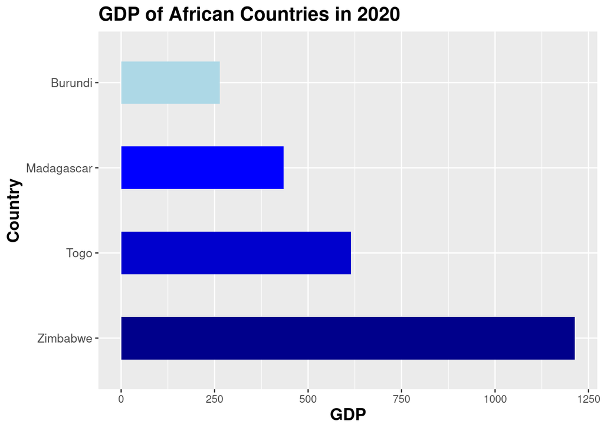

And the poverty percentage of the African countries.

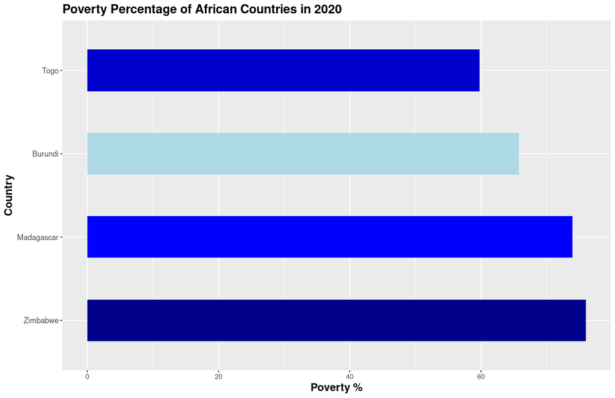

# Scatter Plot

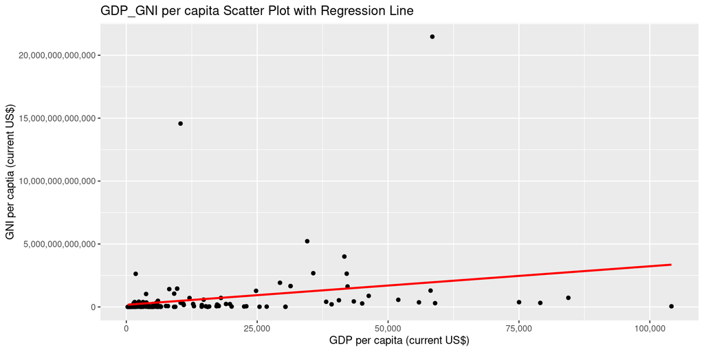

# Time-series Chart

According to the World Bank, the gross domestic product (GDP) of the United States in 2020 was approximately $20.9 trillion.

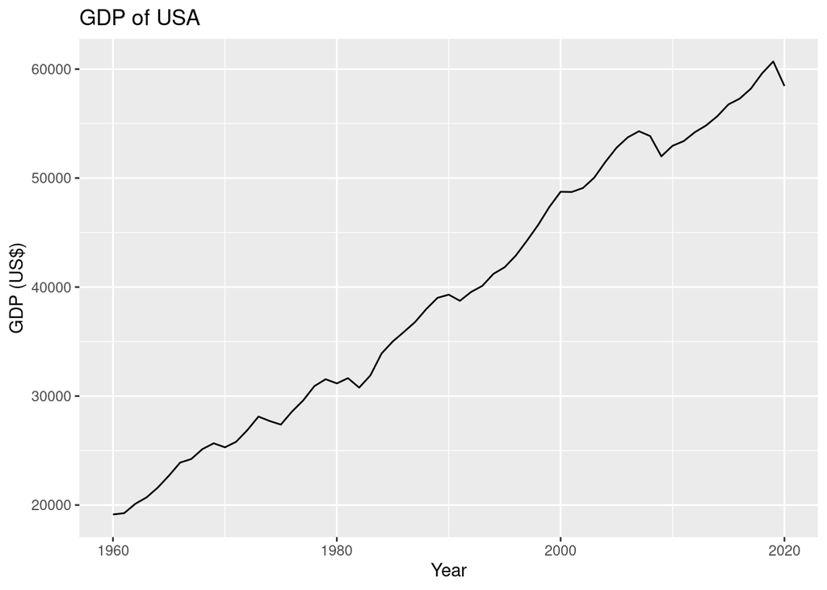

According to the data, Zimbabwe has **75.97 %** of children living in households with income below the national poverty line in 2020.

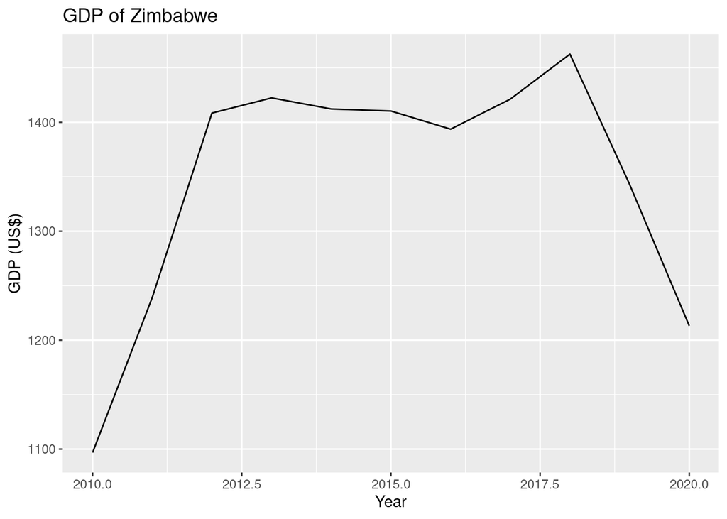